# Implimenting multiple regression algorythms to predict Health Care Cost

#### Seperating numerical features and categorical features

```python
column_int=[]
column_obj=[]
for col in x:
    dataTypeObj = x.dtypes[col]
    if dataTypeObj == np.int64 or dataTypeObj == np.float64 :
        column_int.append(col)
    if dataTypeObj== np.object:
        column_obj.append(col)
```

```python
column_int
```

```
['Item_Visibility', 'Item_MRP']
```

```python
column_obj
```

```
['Item_Fat_Content',
 'Item_Type',
 'Outlet_Size',
 'Outlet_Location_Type',
 'Outlet_Type']
```

##### Checking for irregularities in categorical features

Checking unique values

```python
for i in column_obj:
    print("_"*50)
    print("Column name:", i)
    display(x[i].value_counts())
    print("_"*50)
```

```
__________________________________________________
Column name: Item_Fat_Content
```

```
Low Fat    5089
Regular    2889
LF          316
reg         117
low fat     112
Name: Item_Fat_Content, dtype: int64
```

```
__________________________________________________
__________________________________________________
Column name: Item_Type
```

```
Fruits and Vegetables    1232
Snack Foods              1200
Household                 910
Frozen Foods              856
Dairy                     682
Canned                    649
Baking Goods              648
Health and Hygiene        520
Soft Drinks               445
Meat                      425
Breads                    251
Hard Drinks               214
Others                    169
Starchy Foods             148
Breakfast                 110
Seafood                    64
Name: Item_Type, dtype: int64
```

```
__________________________________________________
__________________________________________________
Column name: Outlet_Size
```

```
Medium    2793
Small     2388
High       932
Name: Outlet_Size, dtype: int64
```

```
__________________________________________________
__________________________________________________
Column name: Outlet_Location_Type
```

```
Tier 3    3350
Tier 2    2785
Tier 1    2388
Name: Outlet_Location_Type, dtype: int64
```

```
__________________________________________________
__________________________________________________
Column name: Outlet_Type
```

```
Supermarket Type1    5577
Grocery Store        1083
Supermarket Type3     935
Supermarket Type2     928
Name: Outlet_Type, dtype: int64
```

```
__________________________________________________
```

In **Item_Fat_Content** feature, we have values **Low Fat, Regular, LF, reg, low fat** . But Low Fat, low fat and LF are same. Regular and reg are the same. So we can replace LF, Low Fat with Low_Fat, reg with Regular_Fat.

```python
x["Item_Fat_Content"].value_counts()
```

```
Low Fat    5089
Regular    2889
LF          316
reg         117
low fat     112
Name: Item_Fat_Content, dtype: int64
```

```python
def replace_word(dataframe):
    dataframe['Item_Fat_Content']=dataframe['Item_Fat_Content'].str.replace('LF','Low_Fat')
    dataframe['Item_Fat_Content']=dataframe['Item_Fat_Content'].str.replace('Low Fat','Low_Fat')
    dataframe['Item_Fat_Content']=dataframe['Item_Fat_Content'].str.replace('low fat','Low_Fat')
    dataframe['Item_Fat_Content']=dataframe['Item_Fat_Content'].str.replace('Regular','Regular_Fat')
    dataframe['Item_Fat_Content']=dataframe['Item_Fat_Content'].str.replace('reg','Regular_Fat')
    return dataframe
```

```python
x=replace_word(x)
```

```python
for i in column_obj:
    print("_"*50)
    print("Column name:", i)
    display(x[i].value_counts())
    print("_"*50)
```

```
__________________________________________________
Column name: Item_Fat_Content
```

```
Low_Fat        5517
Regular_Fat    3006
Name: Item_Fat_Content, dtype: int64
```

```
__________________________________________________
__________________________________________________
Column name: Item_Type
```

```
Fruits and Vegetables    1232
Snack Foods              1200
Household                 910
Frozen Foods              856
Dairy                     682
Canned                    649
Baking Goods              648
Health and Hygiene        520
Soft Drinks               445
Meat                      425
Breads                    251
Hard Drinks               214
Others                    169
Starchy Foods             148
Breakfast                 110
Seafood                    64
Name: Item_Type, dtype: int64
```

```
__________________________________________________
__________________________________________________
Column name: Outlet_Size
```

```
Medium    2793
Small     2388
High       932
Name: Outlet_Size, dtype: int64
```

```
__________________________________________________
__________________________________________________
Column name: Outlet_Location_Type
```

```
Tier 3    3350
Tier 2    2785
Tier 1    2388
Name: Outlet_Location_Type, dtype: int64
```

```
__________________________________________________
__________________________________________________
Column name: Outlet_Type
```

```
Supermarket Type1    5577
Grocery Store        1083
Supermarket Type3     935
Supermarket Type2     928
Name: Outlet_Type, dtype: int64
```

```
__________________________________________________
```

```python
x.head()
```

|  | Item_Fat_Content | Item_Visibility | Item_Type | Item_MRP | Outlet_Size | Outlet_Location_Type | Outlet_Type |
| --- | --- | --- | --- | --- | --- | --- | --- |
| 0 | Low_Fat | 0.016047 | Dairy | 249.8092 | Medium | Tier 1 | Supermarket Type1 |
| 1 | Regular_Fat | 0.019278 | Soft Drinks | 48.2692 | Medium | Tier 3 | Supermarket Type2 |
| 2 | Low_Fat | 0.016760 | Meat | 141.6180 | Medium | Tier 1 | Supermarket Type1 |
| 3 | Regular_Fat | 0.000000 | Fruits and Vegetables | 182.0950 | NaN | Tier 3 | Grocery Store |
| 4 | Low_Fat | 0.000000 | Household | 53.8614 | High | Tier 3 | Supermarket Type1 |

##### Checking for null values

```python
x.isnull().sum()
```

```
Item_Fat_Content           0
Item_Visibility            0
Item_Type                  0
Item_MRP                   0
Outlet_Size             2410
Outlet_Location_Type       0
Outlet_Type                0
dtype: int64
```

We have some null values in **Outlet_Size** .

Lets check percentage of null values.

```python
percent_missing = x.isnull().sum() * 100 / len(x)
mis_percent=pd.DataFrame(percent_missing.round(2))
mis_percent
```

|  | 0 |
| --- | --- |
| Item_Fat_Content | 0.00 |
| Item_Visibility | 0.00 |
| Item_Type | 0.00 |
| Item_MRP | 0.00 |
| Outlet_Size | 28.28 |
| Outlet_Location_Type | 0.00 |
| Outlet_Type | 0.00 |

```python
y.isnull().sum()
```

```
0
```

Handling null values

```python
def handle_null(dataframe, num_column, obj_column):
    for i in dataframe[num_column]:
        dataframe[i]=dataframe[i].fillna(dataframe[i].median())

    for i in dataframe[obj_column]:
        dataframe[i]=dataframe[i].fillna(dataframe[i].mode()[0])

    return dataframe
```

```python
x=handle_null(x, column_int, column_obj)
```

```python
x.isnull().sum()
```

```
Item_Fat_Content        0
Item_Visibility         0
Item_Type               0
Item_MRP                0
Outlet_Size             0
Outlet_Location_Type    0
Outlet_Type             0
dtype: int64
```

##### Checking for outliers

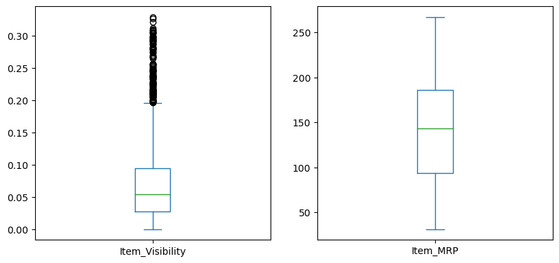

```python
x.plot(kind="box", subplots=True, layout=(3,3), figsize=(15,15));
```

So we have some outliers in **Items_Visibility** feature.

Handling outliers

```python
Q3_item_vis=np.percentile(x["Item_Visibility"], 75)
Q1_item_vis=np.percentile(x["Item_Visibility"], 25)

Q3_Item_MRP=np.percentile(x["Item_MRP"], 75)
Q1_Item_MRP=np.percentile(x["Item_MRP"], 25)
```

```python
def outlier_handle(dataframe):

    IQR_item_vis=Q3_item_vis-Q1_item_vis
    UB_item_vis=Q3_item_vis+(1.5*IQR_item_vis)
    LB_item_vis=Q1_item_vis-(1.5*IQR_item_vis)
    dataframe["Item_Visibility"]=dataframe["Item_Visibility"].apply(lambda x:UB_item_vis if x>UB_item_vis else x)
    dataframe["Item_Visibility"]=dataframe["Item_Visibility"].apply(lambda y:LB_item_vis if y<LB_item_vis else y)



    IQR_Item_MRP=Q3_Item_MRP-Q1_Item_MRP
    UB_Item_MRP=Q3_Item_MRP+(1.5*IQR_Item_MRP)
    LB_Item_MRP=Q1_Item_MRP-(1.5*IQR_Item_MRP)
    dataframe["Item_MRP"]=dataframe["Item_MRP"].apply(lambda x:UB_Item_MRP if x>UB_Item_MRP else x)
    dataframe["Item_MRP"]=dataframe["Item_MRP"].apply(lambda y:LB_Item_MRP if y<LB_Item_MRP else y)


    return dataframe
```

```python
x=outlier_handle(x)
```

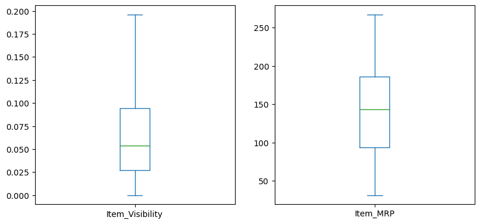

```python
x.plot(kind="box", subplots=True, layout=(3,3), figsize=(15,15));
```

We removed outliers

##### Checking ditribution of output feature

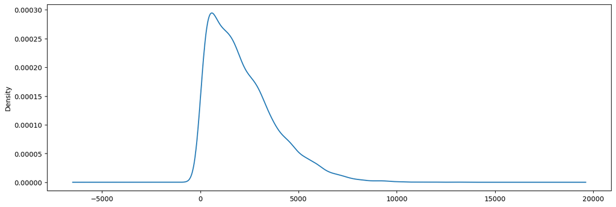

```python
y.plot(kind='kde', figsize=(15,5));
```

Output feature is right skewed, so we have to aply log transformation to make it normally distributed.

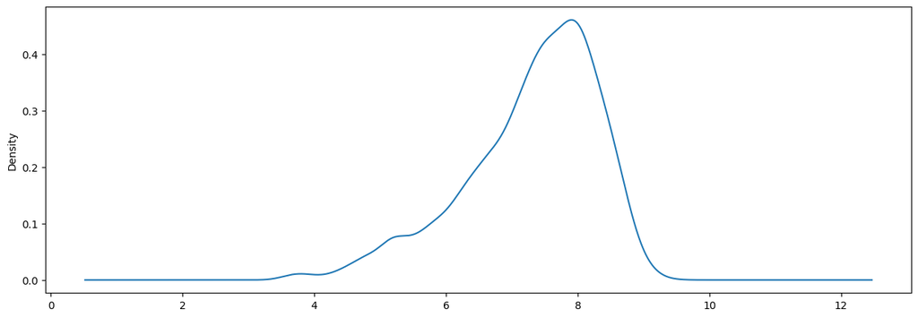

```python
y=np.log(y)
y.plot(kind='kde', figsize=(15,5));
```

##### Converting Categorical features into numerical features

Exploring categorical features with their **category** and **count of each category**

```python
for i in column_obj:
    print("_"*50)
    print("Column name:", i)
    display(x[i].value_counts())
    print("_"*50)
```

```
__________________________________________________
Column name: Item_Fat_Content
```

```
Low_Fat        5517
Regular_Fat    3006
Name: Item_Fat_Content, dtype: int64
```

```
__________________________________________________
__________________________________________________
Column name: Item_Type
```

```
Fruits and Vegetables    1232
Snack Foods              1200
Household                 910
Frozen Foods              856
Dairy                     682
Canned                    649
Baking Goods              648
Health and Hygiene        520
Soft Drinks               445
Meat                      425
Breads                    251
Hard Drinks               214
Others                    169
Starchy Foods             148
Breakfast                 110
Seafood                    64
Name: Item_Type, dtype: int64
```

```
__________________________________________________
__________________________________________________
Column name: Outlet_Size
```

```
Medium    5203
Small     2388
High       932
Name: Outlet_Size, dtype: int64
```

```
__________________________________________________
__________________________________________________
Column name: Outlet_Location_Type
```

```
Tier 3    3350
Tier 2    2785
Tier 1    2388
Name: Outlet_Location_Type, dtype: int64
```

```
__________________________________________________
__________________________________________________
Column name: Outlet_Type
```

```
Supermarket Type1    5577
Grocery Store        1083
Supermarket Type3     935
Supermarket Type2     928
Name: Outlet_Type, dtype: int64
```

```
__________________________________________________
```

```python
x.isnull().sum()
```

```
Item_Fat_Content        0
Item_Visibility         0
Item_Type               0
Item_MRP                0
Outlet_Size             0
Outlet_Location_Type    0
Outlet_Type             0
dtype: int64
```

### Exploratory Data Analysis

Since we have lower number of input features so we can visualize relation between all numerical features with output feature.

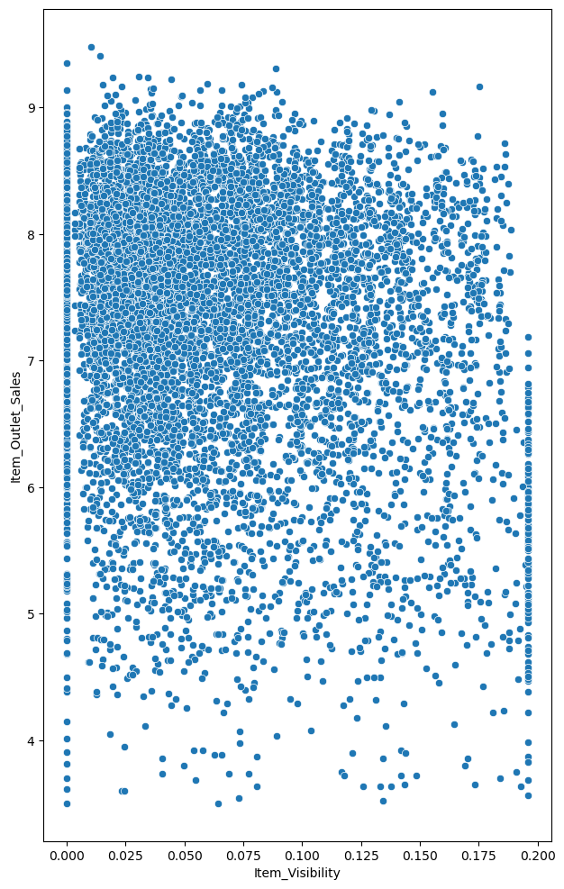

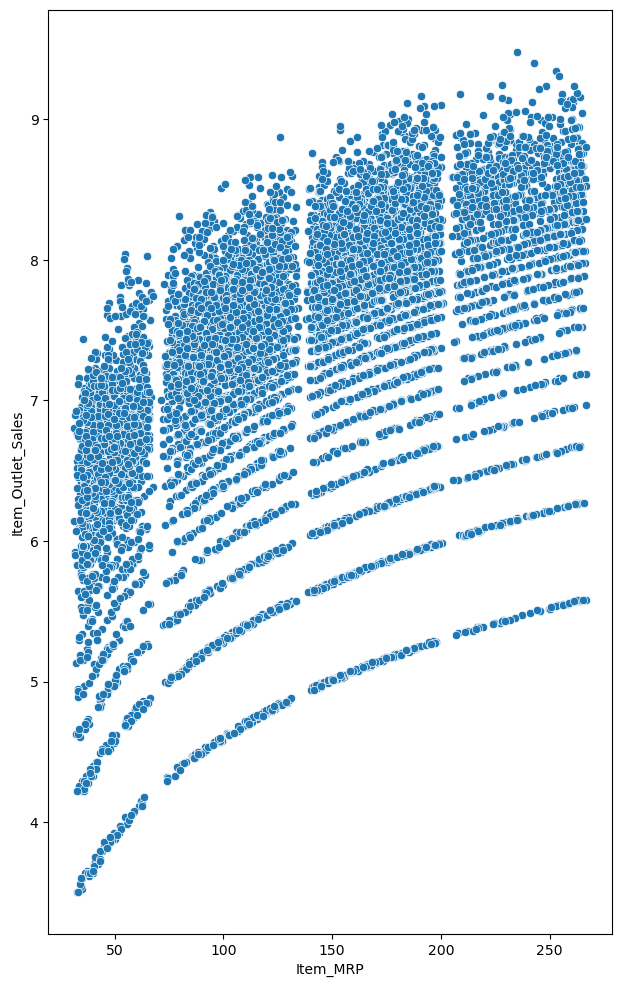

```python
for i in column_int:
    plt.figure(figsize = (16, 12))
    ax = plt.subplot(1,2,2)
    sns.scatterplot(y=y, x=x[i], data=train, ax= ax);
```

1. **Item_Visibility** VS **Item_Outlet_Sales**  
   Item_Outlet_Sales are very high in number, when Item_Visibility in very low
2. **Item_Outlet_Sales** VS **Item_MRP**  
   Number of Item_Outlet_Sales is high when Item_MRP is low, but in this case amount of Item_Outlet_Sales is also low. But when Item_MRP is getting increased, amount of Item_Outlet_Sales is also increasing while Number of Item_Outlet_Sales is getting decreased.

```python
x.head()
```

|  | Item_Fat_Content | Item_Visibility | Item_Type | Item_MRP | Outlet_Size | Outlet_Location_Type | Outlet_Type |
| --- | --- | --- | --- | --- | --- | --- | --- |
| 0 | Low_Fat | 0.016047 | Dairy | 249.8092 | Medium | Tier 1 | Supermarket Type1 |
| 1 | Regular_Fat | 0.019278 | Soft Drinks | 48.2692 | Medium | Tier 3 | Supermarket Type2 |
| 2 | Low_Fat | 0.016760 | Meat | 141.6180 | Medium | Tier 1 | Supermarket Type1 |
| 3 | Regular_Fat | 0.000000 | Fruits and Vegetables | 182.0950 | Medium | Tier 3 | Grocery Store |
| 4 | Low_Fat | 0.000000 | Household | 53.8614 | High | Tier 3 | Supermarket Type1 |

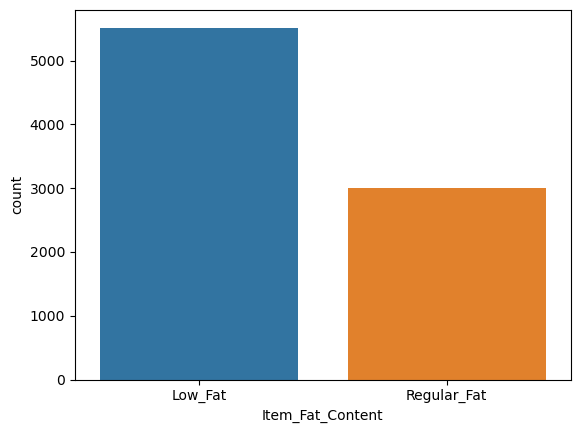

```python
sns.countplot(x='Item_Fat_Content', data=x);
```

Sell of items having low fat is very high than items having regular fat.

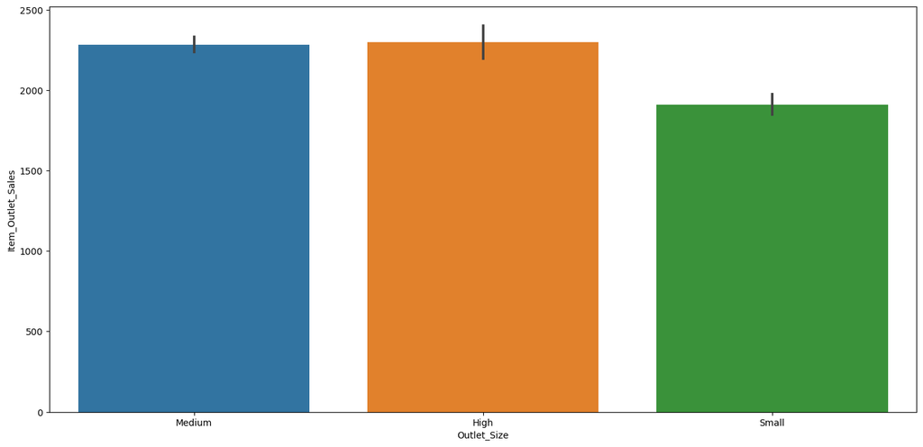

```python
plt.figure(figsize = (17, 8))
sns.barplot(x=x["Outlet_Size"], y=train["Item_Outlet_Sales"])
```

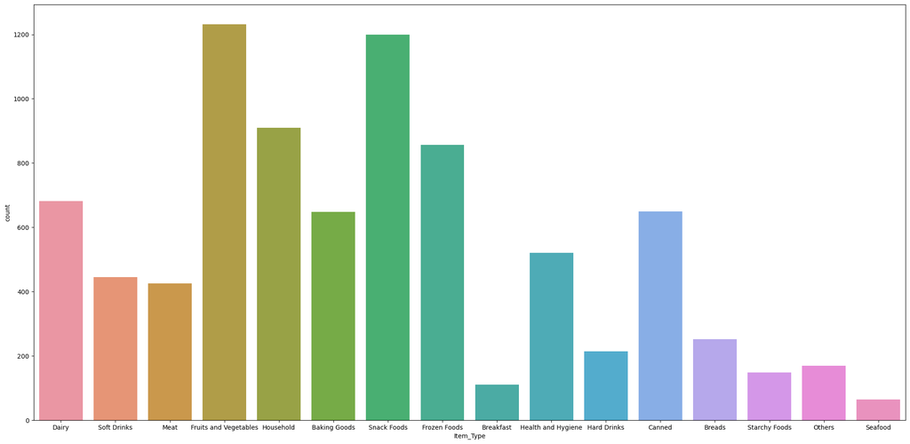

```python
plt.figure(figsize = (25, 12))
sns.countplot(x='Item_Type', data=x);
```

Sell of **fruits and vegitables** , **snack foods** , **Houshold** and **Frozen Foods** are very high in compared with other types of foods while, sell of **Sea Food** , **Breakfast** , **Starchy Foods** is very very low.

##### Converting Categorical features into numerical features

Exploring categorical features with their **category** and **count of each category**

```python
for i in column_obj:
    print("_"*50)
    print("Column name:", i)
    display(x[i].value_counts())
    print("_"*50)
```

```
__________________________________________________
Column name: Item_Fat_Content
```

```
Low_Fat        5517
Regular_Fat    3006
Name: Item_Fat_Content, dtype: int64
```

```
__________________________________________________
__________________________________________________
Column name: Item_Type
```

```
Fruits and Vegetables    1232
Snack Foods              1200
Household                 910
Frozen Foods              856
Dairy                     682
Canned                    649
Baking Goods              648
Health and Hygiene        520
Soft Drinks               445
Meat                      425
Breads                    251
Hard Drinks               214
Others                    169
Starchy Foods             148
Breakfast                 110
Seafood                    64
Name: Item_Type, dtype: int64
```

```
__________________________________________________
__________________________________________________
Column name: Outlet_Size
```

```
Medium    5203
Small     2388
High       932
Name: Outlet_Size, dtype: int64
```

```
__________________________________________________
__________________________________________________
Column name: Outlet_Location_Type
```

```
Tier 3    3350
Tier 2    2785
Tier 1    2388
Name: Outlet_Location_Type, dtype: int64
```

```
__________________________________________________
__________________________________________________
Column name: Outlet_Type
```

```
Supermarket Type1    5577
Grocery Store        1083
Supermarket Type3     935
Supermarket Type2     928
Name: Outlet_Type, dtype: int64
```

```
__________________________________________________
```

```python
def encode_categorical_feature(dataframe, obj_column):
    for i in obj_column:
        dataframe[i]=encoder.fit_transform(dataframe[i])

    return dataframe
```

```python
x=encode_categorical_feature(x, column_obj)
x.head()
```

|  | Item_Fat_Content | Item_Visibility | Item_Type | Item_MRP | Outlet_Size | Outlet_Location_Type | Outlet_Type |
| --- | --- | --- | --- | --- | --- | --- | --- |
| 0 | 0 | 0.016047 | 4 | 249.8092 | 1 | 0 | 1 |
| 1 | 1 | 0.019278 | 14 | 48.2692 | 1 | 2 | 2 |
| 2 | 0 | 0.016760 | 10 | 141.6180 | 1 | 0 | 1 |
| 3 | 1 | 0.000000 | 6 | 182.0950 | 1 | 2 | 0 |
| 4 | 0 | 0.000000 | 9 | 53.8614 | 0 | 2 | 1 |

### Feature Selection

##### Checking for feature importance

```
[0.01293092 0.08196116 0.05674582 0.36232359 0.01460369 0.01466211
 0.45677271]
Plotting graph of feature importances for better visualization
```

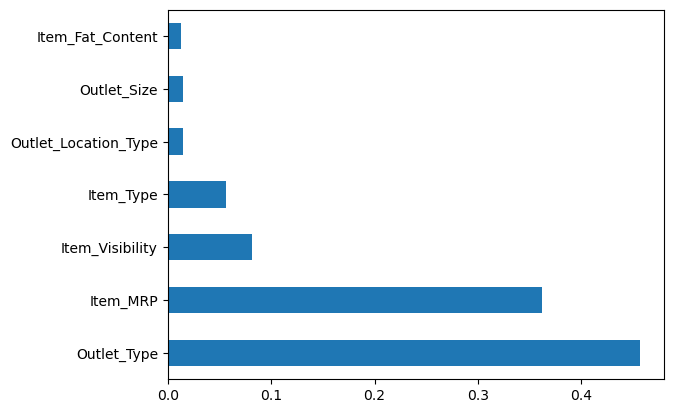

```
______________________________________________________________________
Getting importance of all features in descending order as a dataframe
______________________________________________________________________
```

|  | Features | Importance |
| --- | --- | --- |
| 6 | Outlet_Type | 0.456773 |
| 3 | Item_MRP | 0.362324 |
| 1 | Item_Visibility | 0.081961 |
| 2 | Item_Type | 0.056746 |
| 5 | Outlet_Location_Type | 0.014662 |
| 4 | Outlet_Size | 0.014604 |
| 0 | Item_Fat_Content | 0.012931 |

```python
from sklearn.ensemble import ExtraTreesRegressor
import matplotlib.pyplot as plt
model = ExtraTreesRegressor()
model.fit(x, y)


print(model.feature_importances_)



#plot graph of feature importances for better visualization
print("Plotting graph of feature importances for better visualization")
feat_importances = pd.Series(model.feature_importances_, index=x.columns)
feat_importances.nlargest(x.shape[1]).plot(kind='barh')
plt.show()

print("_"*70)
#Getting importance of all features in descending order as a dataframe
print("Getting importance of all features in descending order as a dataframe")
print("_"*70)
feat_importances.sort_values(ascending=False)
feature_df=feat_importances.to_frame()
DF=feat_importances.reset_index().rename(columns={"index":"Features", 0:"Importance"})
DF=DF.sort_values(by=['Importance'], ascending=False)
display(DF)
```

##### Correlation and Heatmap

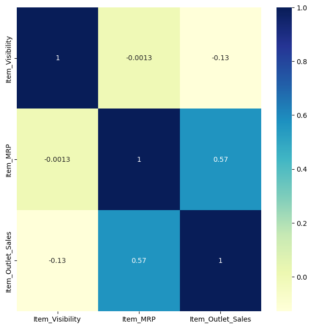

```python
plt.figure(figsize = (8,8))
sns.heatmap(train.drop(unnecesarry_feature, axis=1).corr(), cmap="YlGnBu", annot=True)
plt.show()
```

So we do not have any features that is highly correlated with other feature.

##### Data Scaling

```python
def scale_data(x):
    scale.fit(x)
    x_scaled=scale.transform(x)

    x=pd.DataFrame(data=x_scaled, columns=x.columns)

    return x
```

```python
x=scale_data(x)
```

```python
x.head()
```

|  | Item_Fat_Content | Item_Visibility | Item_Type | Item_MRP | Outlet_Size | Outlet_Location_Type | Outlet_Type |
| --- | --- | --- | --- | --- | --- | --- | --- |
| 0 | -0.738147 | -1.008628 | -0.766479 | 1.747454 | -0.284581 | -1.369334 | -0.252658 |
| 1 | 1.354743 | -0.942473 | 1.608963 | -1.489023 | -0.284581 | 1.091569 | 1.002972 |
| 2 | -0.738147 | -0.994034 | 0.658786 | 0.010040 | -0.284581 | -1.369334 | -0.252658 |
| 3 | 1.354743 | -1.337208 | -0.291391 | 0.660050 | -0.284581 | 1.091569 | -1.508289 |
| 4 | -0.738147 | -1.337208 | 0.421242 | -1.399220 | -1.950437 | 1.091569 | -0.252658 |

```python
from sklearn.model_selection import train_test_split
x_train, x_test, y_train, y_test=train_test_split(x, y, train_size=0.70)
print("Shape of X train:",x_train.shape)
print("Shape of Y train:",y_train.shape)
print("Shape of X test:",x_test.shape)
print("Shape of Y test:",y_test.shape)
```

```
Shape of X train: (5966, 7)
Shape of Y train: (5966,)
Shape of X test: (2557, 7)
Shape of Y test: (2557,)
```

### Model Training and Evaluations of models

```python
def model_evaluate(y_test,y_pred):
    mae = mean_absolute_error(y_test, y_pred)
    mse = mean_squared_error(y_test, y_pred)
    r2 = r2_score(y_test, y_pred)
    print('MAE is {}'.format(round(mae, 3)))
    print('MSE is {}'.format(round(mse, 3)))
    print('R2 score is {}'.format(round(r2, 3)))
```

```python
from sklearn.metrics import mean_absolute_error, mean_squared_error, r2_score
from sklearn.model_selection import GridSearchCV
from sklearn.model_selection import KFold
```

##### Linear Regression

```python
from sklearn.linear_model import LinearRegression
lr=LinearRegression()
lr.fit(x_train, y_train)
y_pred_lr=lr.predict(x_test)
print("Scores of Linear Regression:")
model_evaluate(y_test,y_pred_lr)

print("Train Accuracy:",lr.score(x_train, y_train))
print("Test Accuracy:",lr.score(x_test, y_test))
```

```
Scores of Linear Regression:
MAE is 0.535
MSE is 0.455
R2 score is 0.563
Train Accuracy: 0.5589956865704904
Test Accuracy: 0.5627905237191861
```

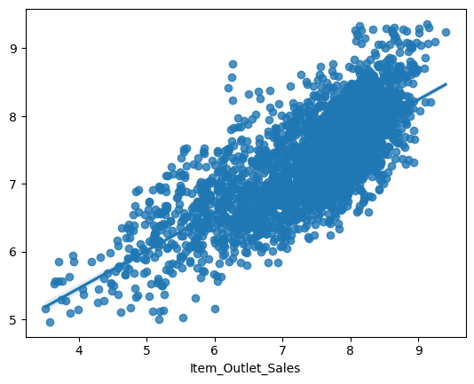

```python
pickle.dump(lr, open('linear_regressor.pkl', 'wb'))
sns.regplot(x=y_test,y=y_pred_lr)
plt.show()
```

##### Decision Tree Regressor

```python
from sklearn.tree import DecisionTreeRegressor

dt = DecisionTreeRegressor()
parameter={"max_depth" : [1, 2, 3, 4, 5, 6, 7, 8, 9, 10, 11, 12, 13, 14, 15],
          "criterion":["squared_error", "friedman_mse", "absolute_error"],
          "splitter":["best", "random"]}
kf=KFold(n_splits=10)
grid_sv = GridSearchCV(dt, cv=kf, param_grid=parameter, scoring='neg_mean_absolute_error')
grid_sv.fit(x_train, y_train)
param_dict_dt=dict(grid_sv.best_params_)

DT=DecisionTreeRegressor(criterion=param_dict_dt["criterion"],
                         max_depth=param_dict_dt["max_depth"],
                         splitter= param_dict_dt["splitter"])
DT.fit(x_train, y_train)
y_pred_DT=DT.predict(x_test)
print("Scores of DT Regression:")
model_evaluate(y_test,y_pred_DT)
print("Train Accuracy:",DT.score(x_train, y_train))
print("Test Accuracy:",DT.score(x_test, y_test))
```

```
Scores of DT Regression:
MAE is 0.4
MSE is 0.279
R2 score is 0.732
Train Accuracy: 0.7308504405658648
Test Accuracy: 0.7319758403327312
```

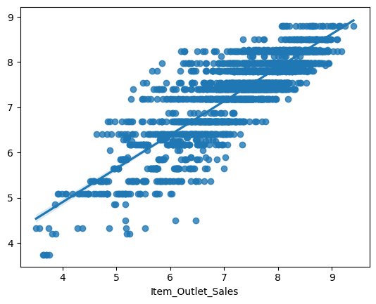

```python
pickle.dump(DT, open('decision_tree_regressor.pkl', 'wb'))
sns.regplot(x=y_test,y=y_pred_DT)
plt.show()
```

##### Random Forest Regressor

```python
from sklearn.ensemble import RandomForestRegressor

rf = RandomForestRegressor()
parameter={"max_depth" : [1, 2, 3, 4, 5, 6, 7, 8, 9, 10, 11],
          "criterion":["squared_error", "absolute_error", "poisson"],
          "max_features":["auto", "sqrt", "log2"],
          "n_jobs":[10]}
kf=KFold(n_splits=10)
grid_rf = GridSearchCV(rf, cv=kf, param_grid=parameter, scoring='neg_mean_absolute_error')
grid_rf.fit(x_train, y_train)
param_dict_rf=dict(grid_rf.best_params_)


RF=RandomForestRegressor(criterion=param_dict_rf["criterion"],
                         max_depth=param_dict_rf["max_depth"],
                         max_features= param_dict_rf["max_features"])

RF.fit(x_train, y_train)
y_pred_RF=RF.predict(x_test)
print("Scores of RF Regression:")
model_evaluate(y_test,y_pred_RF)

print("Train Accuracy:",RF.score(x_train, y_train))
print("Test Accuracy:",RF.score(x_test, y_test))
```

```
Scores of RF Regression:
MAE is 0.398
MSE is 0.273
R2 score is 0.738
Train Accuracy: 0.7483337118182669
Test Accuracy: 0.7382429190578361
```

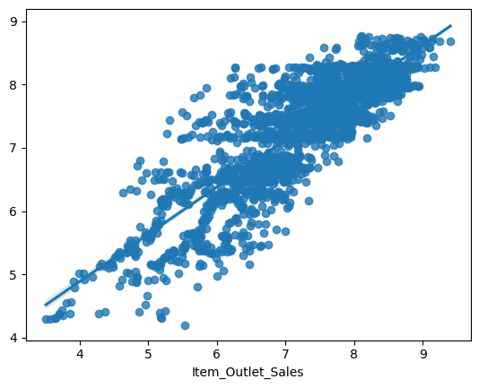

```python
pickle.dump(RF, open('random_forest_regressor.pkl', 'wb'))
sns.regplot(x=y_test,y=y_pred_RF)
plt.show()
```

##### KNN Regressor

```python
from sklearn.neighbors import KNeighborsRegressor

knn = KNeighborsRegressor()
parameter={"n_neighbors" : [3, 4, 5, 6, 7, 8, 9, 10, 11, 12, 13],
          "weights":['uniform', 'distance'],
          "algorithm":['auto', 'ball_tree', 'kd_tree', 'brute'],
          "n_jobs":[10]}
kf=KFold(n_splits=10)
grid_knn = GridSearchCV(knn, cv=kf, param_grid=parameter, scoring='neg_mean_absolute_error')
grid_knn.fit(x_train, y_train)
param_dict_knn=dict(grid_knn.best_params_)

KNN=KNeighborsRegressor(n_neighbors=param_dict_knn["n_neighbors"],
                        weights=param_dict_knn["weights"],
                        algorithm= param_dict_knn["algorithm"])
KNN.fit(x_train, y_train)
y_pred_KNN=KNN.predict(x_test)
print("Scores of KNN Regression:")
model_evaluate(y_test,y_pred_KNN)

print("Train Accuracy:",KNN.score(x_train, y_train))
print("Test Accuracy:",KNN.score(x_test, y_test))
```

```
Scores of KNN Regression:
MAE is 0.423
MSE is 0.299
R2 score is 0.713
Train Accuracy: 0.7412335463715811
Test Accuracy: 0.7130261834705927
```

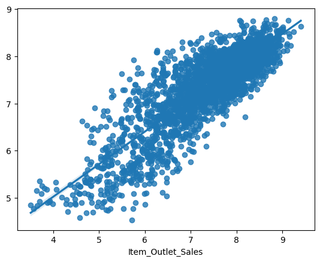

```python
pickle.dump(KNN, open('knn_regressor.pkl', 'wb'))
sns.regplot(x=y_test,y=y_pred_KNN)
plt.show()
```

##### Gradient Boost Regressor

```python
from sklearn.ensemble import GradientBoostingRegressor

gb = GradientBoostingRegressor()
parameter={"loss" : ['squared_error', 'absolute_error'],
          "criterion":['squared_error', 'mse', 'mae'],
          "max_depth":[1, 2, 3, 4, 5, 6, 7, 8, 9, 10],
           "max_features":['auto', 'sqrt', 'log2']}

kf=KFold(n_splits=10)
grid_gb = GridSearchCV(gb, cv=kf, param_grid=parameter, scoring='neg_mean_absolute_error')
grid_gb.fit(x_train, y_train)
param_dict_gb=dict(grid_gb.best_params_)

GB=GradientBoostingRegressor(loss=param_dict_gb["loss"],
                             criterion=param_dict_gb["criterion"],
                             max_depth= param_dict_gb["max_depth"],
                             max_features=param_dict_gb["max_features"])
GB.fit(x_train, y_train)
y_pred_GB=GB.predict(x_test)
print("Scores of GB Regression:")
model_evaluate(y_test,y_pred_GB)

print("Train Accuracy:",GB.score(x_train, y_train))
print("Test Accuracy:",GB.score(x_test, y_test))
```

```
Scores of GB Regression:
MAE is 0.396
MSE is 0.271
R2 score is 0.74
Train Accuracy: 0.7436808039180769
Test Accuracy: 0.7402376384173353
```

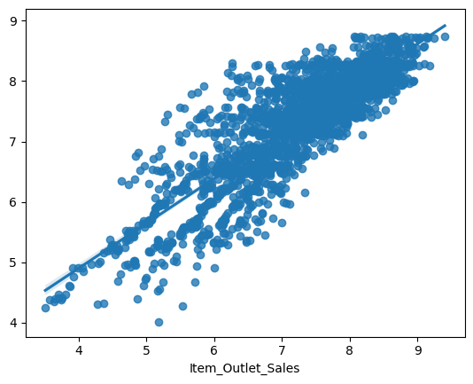

```python
pickle.dump(GB, open('gradient_boost_regressor.pkl', 'wb'))
sns.regplot(x=y_test,y=y_pred_GB)
plt.show()
```

##### Creating dataframe with MAE, MSE and R2-Score of all trained models to better visualization

```python
regressors = {
    'Linear Regression' : lr,
    'Decision Tree' : DT,
    'Random Forest' : RF,
    'K-nearest Neighbors' : KNN,
    'Gradient Boost' : GB
}
results=pd.DataFrame(columns=['Train Score', 'Test Score', 'MAE', 'MSE', 'R2-score'])
for method,func in regressors.items():
    pred = func.predict(x_test)
    results.loc[method]= [
                          func.score(x_train, y_train),
                          func.score(x_test, y_test),
                          np.round(mean_absolute_error(y_test,pred),3),
                          np.round(mean_squared_error(y_test,pred),3),
                          np.round(r2_score(y_test,pred),3)
                         ]

final_result=results.sort_values('R2-score',ascending=False).style.background_gradient(cmap='Greens',subset=['R2-score'])
display(final_result)
```

|  | Train Score | Test Score | MAE | MSE | R2-score |
| --- | --- | --- | --- | --- | --- |
| Gradient Boost | 0.743681 | 0.740238 | 0.396000 | 0.271000 | 0.740000 |
| Random Forest | 0.748334 | 0.738243 | 0.398000 | 0.273000 | 0.738000 |
| Decision Tree | 0.730850 | 0.731976 | 0.400000 | 0.279000 | 0.732000 |
| K-nearest Neighbors | 0.741234 | 0.713026 | 0.423000 | 0.299000 | 0.713000 |
| Linear Regression | 0.558996 | 0.562791 | 0.535000 | 0.455000 | 0.563000 |

Out of all models, Gradient Boost works the bestwith accuracy 0f 74%

### Predicting with all new datas

```python
test.head()
```

|  | Item_Identifier | Item_Weight | Item_Fat_Content | Item_Visibility | Item_Type | Item_MRP | Outlet_Identifier | Outlet_Establishment_Year | Outlet_Size | Outlet_Location_Type | Outlet_Type |
| --- | --- | --- | --- | --- | --- | --- | --- | --- | --- | --- | --- |
| 0 | FDW58 | 20.750 | Low Fat | 0.007565 | Snack Foods | 107.8622 | OUT049 | 1999 | Medium | Tier 1 | Supermarket Type1 |
| 1 | FDW14 | 8.300 | reg | 0.038428 | Dairy | 87.3198 | OUT017 | 2007 | NaN | Tier 2 | Supermarket Type1 |
| 2 | NCN55 | 14.600 | Low Fat | 0.099575 | Others | 241.7538 | OUT010 | 1998 | NaN | Tier 3 | Grocery Store |
| 3 | FDQ58 | 7.315 | Low Fat | 0.015388 | Snack Foods | 155.0340 | OUT017 | 2007 | NaN | Tier 2 | Supermarket Type1 |
| 4 | FDY38 | NaN | Regular | 0.118599 | Dairy | 234.2300 | OUT027 | 1985 | Medium | Tier 3 | Supermarket Type3 |

##### Drop unnecesarry features

```python
X_test=test.copy()
X_test.drop(unnecesarry_feature, inplace=True, axis=1)
X_test.head()
```

|  | Item_Fat_Content | Item_Visibility | Item_Type | Item_MRP | Outlet_Size | Outlet_Location_Type | Outlet_Type |
| --- | --- | --- | --- | --- | --- | --- | --- |
| 0 | Low Fat | 0.007565 | Snack Foods | 107.8622 | Medium | Tier 1 | Supermarket Type1 |
| 1 | reg | 0.038428 | Dairy | 87.3198 | NaN | Tier 2 | Supermarket Type1 |
| 2 | Low Fat | 0.099575 | Others | 241.7538 | NaN | Tier 3 | Grocery Store |
| 3 | Low Fat | 0.015388 | Snack Foods | 155.0340 | NaN | Tier 2 | Supermarket Type1 |
| 4 | Regular | 0.118599 | Dairy | 234.2300 | Medium | Tier 3 | Supermarket Type3 |

##### Replace irregular strings with proper string

```python
X_test=replace_word(X_test)
X_test.head()
```

|  | Item_Fat_Content | Item_Visibility | Item_Type | Item_MRP | Outlet_Size | Outlet_Location_Type | Outlet_Type |
| --- | --- | --- | --- | --- | --- | --- | --- |
| 0 | Low_Fat | 0.007565 | Snack Foods | 107.8622 | Medium | Tier 1 | Supermarket Type1 |
| 1 | Regular_Fat | 0.038428 | Dairy | 87.3198 | NaN | Tier 2 | Supermarket Type1 |
| 2 | Low_Fat | 0.099575 | Others | 241.7538 | NaN | Tier 3 | Grocery Store |
| 3 | Low_Fat | 0.015388 | Snack Foods | 155.0340 | NaN | Tier 2 | Supermarket Type1 |
| 4 | Regular_Fat | 0.118599 | Dairy | 234.2300 | Medium | Tier 3 | Supermarket Type3 |

##### Check for null values

```python
X_test.isnull().sum()
```

```
Item_Fat_Content           0
Item_Visibility            0
Item_Type                  0
Item_MRP                   0
Outlet_Size             1606
Outlet_Location_Type       0
Outlet_Type                0
dtype: int64
```

```python
X_test=handle_null(X_test, column_int, column_obj)
```

```python
X_test.isnull().sum()
```

```
Item_Fat_Content        0
Item_Visibility         0
Item_Type               0
Item_MRP                0
Outlet_Size             0
Outlet_Location_Type    0
Outlet_Type             0
dtype: int64
```

##### Checking for outliers

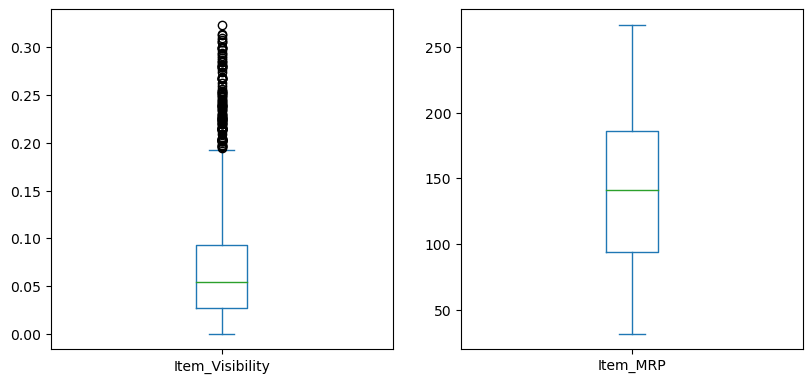

```python
X_test.plot(kind="box", subplots=True, layout=(3,3), figsize=(15,15));
```

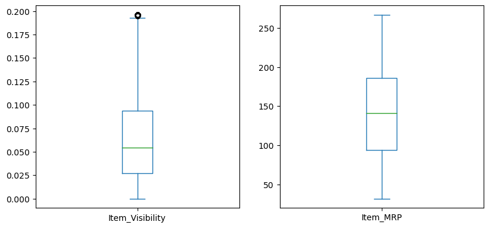

```python
X_test=outlier_handle(X_test)
X_test.plot(kind="box", subplots=True, layout=(3,3), figsize=(15,15));
```

##### Categorical to numerical features

```python
X_test=encode_categorical_feature(X_test, column_obj)
X_test.head()
```

|  | Item_Fat_Content | Item_Visibility | Item_Type | Item_MRP | Outlet_Size | Outlet_Location_Type | Outlet_Type |
| --- | --- | --- | --- | --- | --- | --- | --- |
| 0 | 0 | 0.007565 | 13 | 107.8622 | 1 | 0 | 1 |
| 1 | 1 | 0.038428 | 4 | 87.3198 | 1 | 1 | 1 |
| 2 | 0 | 0.099575 | 11 | 241.7538 | 1 | 2 | 0 |
| 3 | 0 | 0.015388 | 13 | 155.0340 | 1 | 1 | 1 |
| 4 | 1 | 0.118599 | 4 | 234.2300 | 1 | 2 | 3 |

##### Scale the data

```python
X_test=scale.transform(X_test)
X_test=pd.DataFrame(data=X_test, columns=x.columns)
X_test.head()
```

|  | Item_Fat_Content | Item_Visibility | Item_Type | Item_MRP | Outlet_Size | Outlet_Location_Type | Outlet_Type |
| --- | --- | --- | --- | --- | --- | --- | --- |
| 0 | -0.738147 | -1.182313 | 1.371418 | -0.532035 | -0.284581 | -1.369334 | -0.252658 |
| 1 | 1.354743 | -0.550374 | -0.766479 | -0.861920 | -0.284581 | -0.138882 | -0.252658 |
| 2 | -0.738147 | 0.701661 | 0.896330 | 1.618094 | -0.284581 | 1.091569 | -1.508289 |
| 3 | -0.738147 | -1.022120 | 1.371418 | 0.225484 | -0.284581 | -0.138882 | -0.252658 |
| 4 | 1.354743 | 1.091199 | -0.766479 | 1.497272 | -0.284581 | 1.091569 | 2.258603 |

##### Predict with the data

```python
model_prediction=GB.predict(X_test)
```

Since we used log to transform skewed output feature to make it normally distributed. So we have to use antilog of predicted values to get correct prediction.

```python
model_prediction=np.exp(model_prediction)
```

```python
model_prediction=pd.DataFrame(data=model_prediction, columns=["Predicted Values"])
model_prediction.head()
```

|  | Predicted Values |
| --- | --- |
| 0 | 1710.175904 |
| 1 | 1233.107924 |
| 2 | 498.811771 |
| 3 | 2491.234074 |
| 4 | 6105.250520 |

```python
minimum_train=train['Item_Outlet_Sales'].min()
maximum_train= train['Item_Outlet_Sales'].max()


display("Minimum output value of actual data set ",minimum_train)
display("Maximum output value of actual data set ",maximum_train)
```

```
'Minimum output value of actual data set '
```

```
33.29
```

```
'Maximum output value of actual data set '
```

```
13086.9648
```

```python
minimum_test=model_prediction['Predicted Values'].min()
maximum_test= model_prediction['Predicted Values'].max()


display("Minimum output value of new data set ",minimum_test)
display("Maximum output value of new data set ",maximum_test)
```

```
'Minimum output value of new data set '
```

```
45.639827399152935
```

```
'Maximum output value of new data set '
```

```
7292.355682904377
```